# 2024_06_Chlorophyll_Abundance

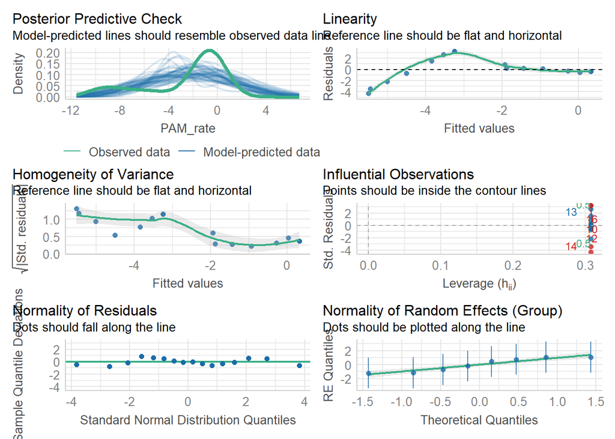

```r
check_model(pam_norm_lmer)
```

```r
tide_PAM <- norm_PAM_weight_tide %>%
  filter(Plate_Type != "Control",
         !Group %in% c(2,7,9))
pam_tide_lmer <- lmer(log(PAM_rate+10)~Plate_Type+Tide_height_avg+(1|Group), data = tide_PAM)
anova(pam_tide_lmer)
```

```
## Type III Analysis of Variance Table with Satterthwaite's method
##                 Sum Sq Mean Sq NumDF DenDF F value  Pr(>F)
## Plate_Type       3.675   3.675     1    11  4.0803 0.06842 .
## Tide_height_avg  3.100   3.100     1    11  3.4419 0.09054 .
## ---
## Signif. codes:  0 '***' 0.001 '**' 0.01 '*' 0.05 '.' 0.1 ' ' 1
```

```r
summary(pam_tide_lmer)
```

```
## Linear mixed model fit by REML. t-tests use Satterthwaite's method [
## lmerModLmerTest]
## Formula: log(PAM_rate + 10) ~ Plate_Type + Tide_height_avg + (1 | Group)
##    Data: tide_PAM
##
## REML criterion at convergence: 38
##
## Scaled residuals:
##     Min      1Q  Median      3Q     Max
## -2.4629 -0.4378  0.2427  0.5351  1.2948
##
## Random effects:
##  Groups   Name        Variance Std.Dev.
##  Group    (Intercept) 0.0000   0.000
##  Residual             0.9007   0.949
## Number of obs: 14, groups:  Group, 7
##
## Fixed effects:
##                 Estimate Std. Error      df t value Pr(>|t|)
## (Intercept)      -0.5904     1.5603 11.0000  -0.378   0.7124
## Plate_TypeMale   -1.0247     0.5073 11.0000  -2.020   0.0684 .
## Tide_height_avg   0.2298     0.1239 11.0000   1.855   0.0905 .
## ---
## Signif. codes:  0 '***' 0.001 '**' 0.01 '*' 0.05 '.' 0.1 ' ' 1
##
## Correlation of Fixed Effects:
##             (Intr) Plt_TM
## Plate_TypMl -0.163
## Tid_hght_vg -0.973  0.000
## optimizer (nloptwrap) convergence code: 0 (OK)
## boundary (singular) fit: see help('isSingular')
```

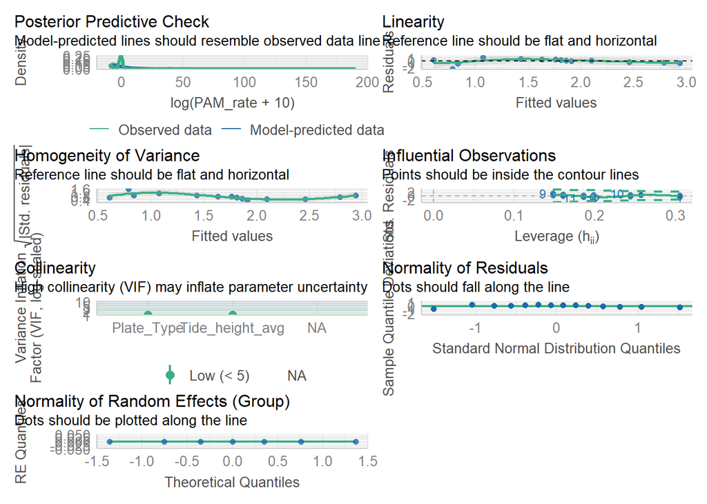

```r
check_model(pam_tide_lmer)
```

```r
ggsave(here("Output", "PAM_Tide_Check_Model.png"))
#sjp.lmer(pam_tide_lmer, type= "pred")
```

#joined normalized PAM and limpet weight boxplots

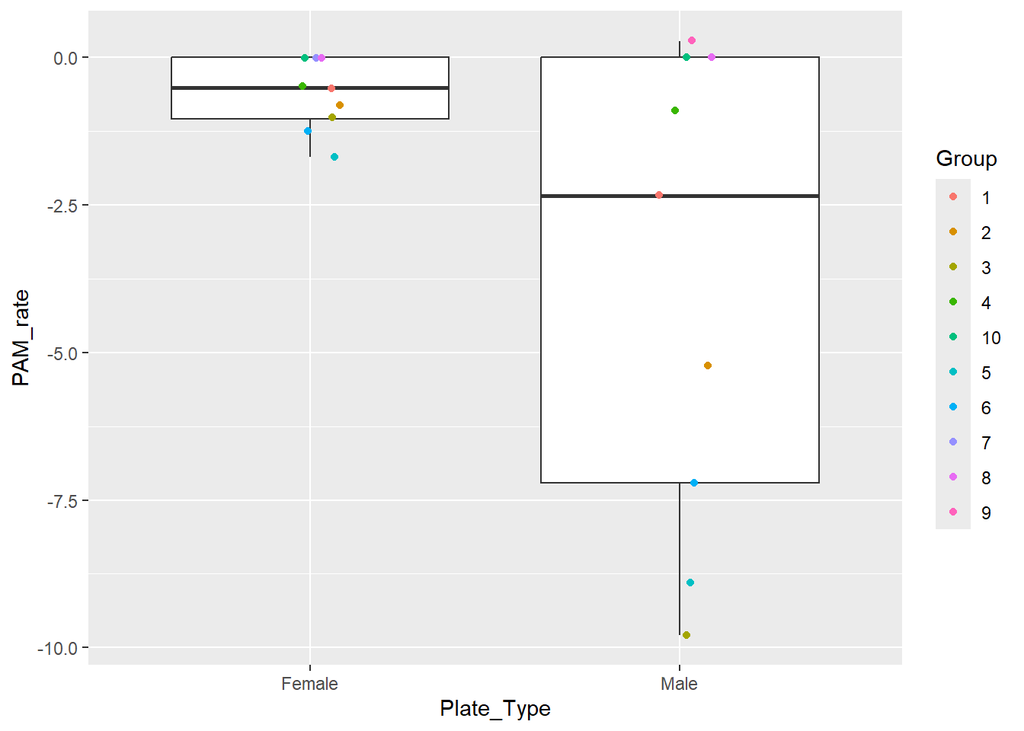

```r
norm_PAM_weight_box <- norm_PAM_weight %>%
  filter(Plate_Type != "Control") %>%
  ggplot(aes(x= Plate_Type,
             y=PAM_rate))+
  geom_boxplot()+
  geom_jitter(width = 0.1,
              aes(color=Group))
norm_PAM_weight_box
```

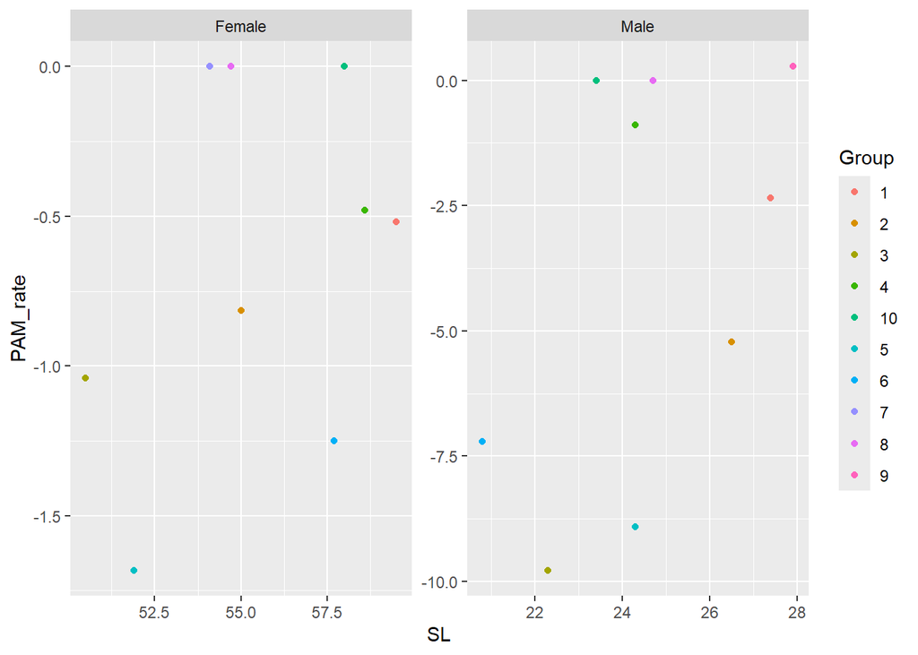

```r
PAM_body_size_scatter <- norm_PAM_weight %>%
  filter(Plate_Type != "Control") %>%
  ggplot(aes(x= SL,
             y = PAM_rate))+
  geom_point(aes(color = Group))+
  facet_wrap(~Plate_Type, scales = "free")
PAM_body_size_scatter
```

#Spectophotometry Data Manipulation

```r
chl_abun <- orig_spec_chl_abun %>%
  separate(col = Plate_ID,
           into = c("Plate", "ID"),
           sep = "_") %>%
  mutate(Path_length_cm = Path_lenght_mm/10) %>%
  mutate(ug_ml = ((Abun_665-Abun_750)/Path_length_cm),
         ug = ug_ml *Metha_vol,
         ug_cm2 = ug/SA_cm_2) %>%
  group_by(Plate, Group) %>%
  summarise(mean_ug_cm2 = mean(ug_cm2 ),
            sd_ug_cm2 = sd(ug_cm2),
            kurtosis_ug_cm2 = kurtosis(ug_cm2),
            se_ug_cm2 = sd(ug_cm2)/sqrt(n())) %>%
  mutate(Group = as.factor(Group))%>%
  mutate(Plate_Type = case_when(
    Plate %in% c("C1","C2","C3","C4") ~ "Control",
    Plate %in% c("F1","F2","F3","F4","F6","F7","F8","F10","F5") ~ "Female",
    Plate %in% c("M1","M2","M3","M4","M5","M6","M8","M9","M10") ~ "Male",
    Plate %in% ("UK") ~ "Unknown"))
```

#Normalized Chlorophyll Data

```r
chl_normalized <- chl_abun %>% #called in df used to calculate chrorophyll abundance from raw data
  group_by(Plate, Group, Plate_Type) %>% #grouped by Plate(Plate ID), Group, and plate type
  filter(Plate != "UK") %>% #filtered out the unknown plate
   mutate(Group_control = case_when(Plate %in% c("C1", "F1", "M1", "F2", "M2", "F3", "M3", "F4", "M4")~1, #this groups to control 1
                                   Plate %in% c("C2", "F5", "M5", "F6", "M6")~2, #this groups to control 2
                                   Plate %in% c("C3", "F7", "M7", "F8", "M8")~3, #this groups to control 3
                                   Plate %in% c("C4", "F9", "M9", "F10", "M10")~4)) %>%  #this groups to control 4
  mutate(Group_control = factor(Group_control), #this makes the group control a factor
         Group = factor(Group)) %>% #this makes group a factor
  ungroup() %>% #ungroup from grouping above
  group_by(Group_control) %>% #now we will group by group control
  mutate(control_mean_ug_cm2 = mean_ug_cm2[Plate_Type=="Control"],
         norm_mean_ug_cm2 = mean_ug_cm2-control_mean_ug_cm2) %>% #this normalizes the mean to the controls)
rename(Plate_ID=Plate)
```

#Normalized Chlorophyll Boxplots

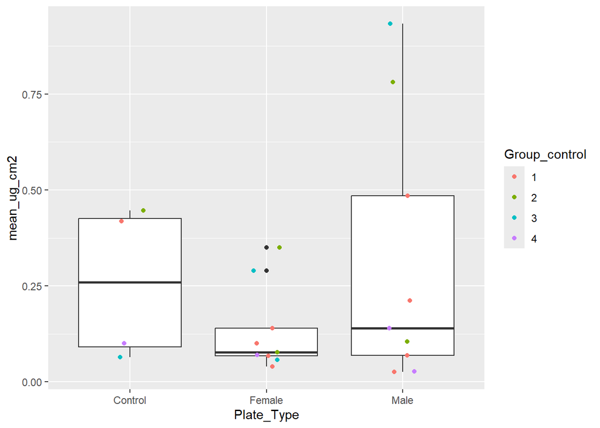

```r
mean_ug_cm2_box <- chl_normalized %>% #this shows us the mean of chlorophyll abundance by plate type
  ggplot(aes(x= Plate_Type,
             y = mean_ug_cm2))+
  geom_boxplot()+
  geom_jitter(width=0.1,
              aes(color = Group_control)) #this is to color by control group
mean_ug_cm2_box
```

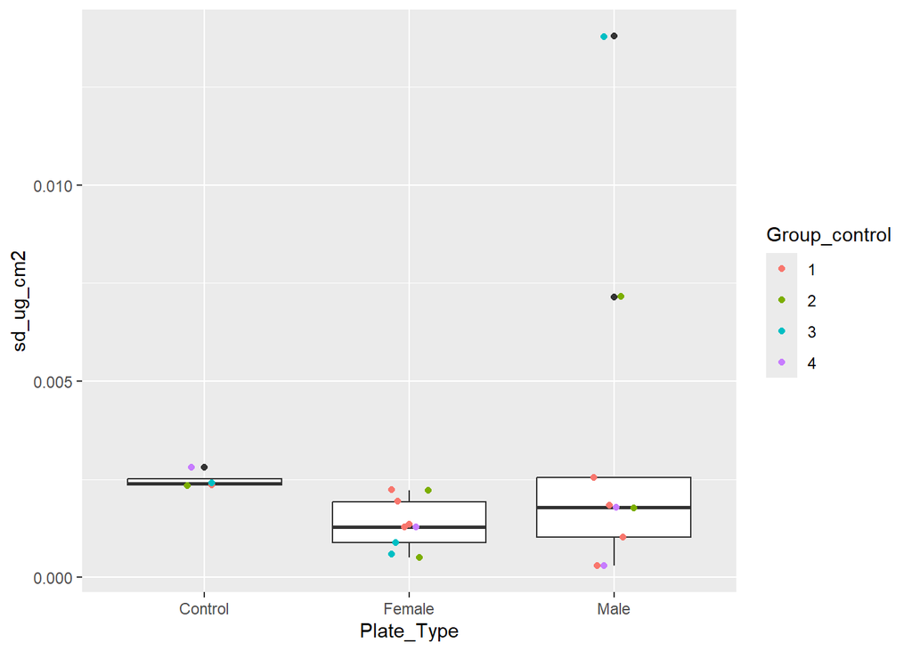

```r
sd_ug_cm2_box <- chl_normalized %>% #this shows us the variance around the mean
  ggplot(aes(x= Plate_Type,
             y = sd_ug_cm2))+
  geom_boxplot()+
  geom_jitter(width = 0.1,
              aes(color = Group_control))
sd_ug_cm2_box
```

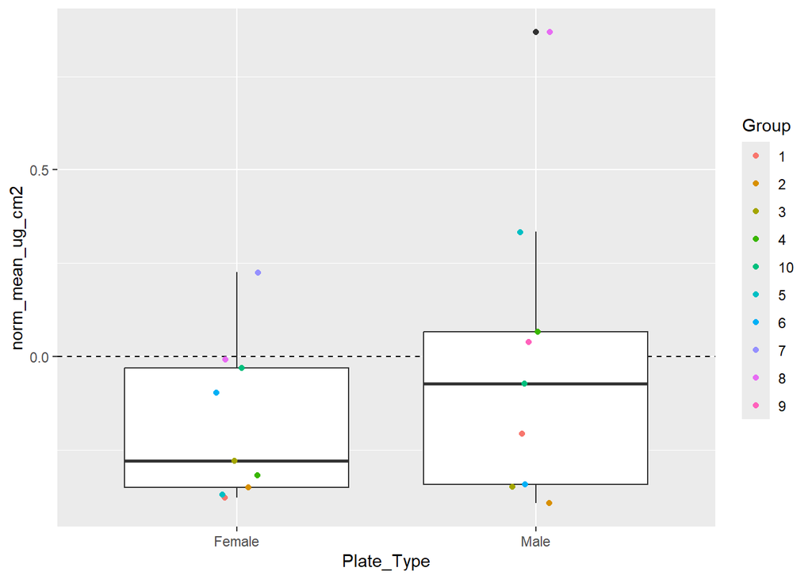

```r
norm_mean_ug_cm2_by_sex_box <- chl_normalized %>% #this shows us the mean once it has been normalized to the appropriate control by plate
  filter(Plate_Type != "Control") %>%
  ggplot(aes(x= Plate_Type,
             y = norm_mean_ug_cm2))+
  geom_hline(yintercept = 0, #this adds a horizontal line
             lty = 2)+ #this makes the line dashed 1= solid line
  geom_boxplot()+
  geom_jitter(width = 0.1,
              aes(color = Group)) #here we group by group 1-10 instead of the group_control since it has been normalized
norm_mean_ug_cm2_by_sex_box
```

```r
#norm_sd_ug_cm2_by_sex_box <- chl_normalized %>% #this shows use the variance around the mean that has been normalized
 # filter(Plate_Type != "Control") %>%
  #ggplot(aes(x= Plate_Type,
   #          y = norm_sd_ug_cm2))+
  #geom_boxplot()+
  #geom_jitter(width = 0.1,
   #           aes(color= Group)) #here we group by group 1-10 instead of the group_control since it has been normalized
#norm_sd_ug_cm2_by_sex_box
```

#joined normalized chl and limpet weight

```r
norm_chl_weight <- left_join(chl_normalized, factor_limpet_weight) %>%
  mutate(chl_rate = norm_mean_ug_cm2/(6.4*WW_g)) # change in chlorophyll per day (6.4 is 6.4 weeks plates were left out) per limpet biomass (wet weight)
##change chl from micrograms to either mg or g or change days to week or take 45 out
norm_chl_weight_tide <- left_join(norm_chl_weight, factor_tide_height)
```

#Linear Models for Normalized Chla and Weight and Tide Height

```r
tide_chl <- norm_chl_weight_tide %>%
  filter(Plate_Type != "Control",
         !Group %in% 2)
chl_tide_lmer <- lmer(log(chl_rate+7)~Plate_Type+Tide_height_avg+(1|Group), data = tide_chl)
anova(chl_tide_lmer)
```

```
## Type III Analysis of Variance Table with Satterthwaite's method
##                     Sum Sq    Mean Sq NumDF DenDF F value Pr(>F)
## Plate_Type      1.0854e-06 1.0854e-06     1    13  0.1173 0.7375
## Tide_height_avg 1.8676e-05 1.8676e-05     1    13  2.0177 0.1790
```

```r
summary(chl_tide_lmer)
```

```
## Linear mixed model fit by REML. t-tests use Satterthwaite's method [
## lmerModLmerTest]
## Formula: log(chl_rate + 7) ~ Plate_Type + Tide_height_avg + (1 | Group)
##    Data: tide_chl
##
## REML criterion at convergence: -105.5
##
## Scaled residuals:
##      Min       1Q   Median       3Q      Max
## -1.40002 -0.43079  0.05489  0.27677  2.33491
##
## Random effects:
##  Groups   Name        Variance  Std.Dev.
##  Group    (Intercept) 0.000e+00 0.000000
##  Residual             9.256e-06 0.003042
## Number of obs: 16, groups:  Group, 9
##
## Fixed effects:
##                  Estimate Std. Error        df t value Pr(>|t|)
## (Intercept)     1.939e+00  4.792e-03 1.300e+01 404.635   <2e-16 ***
## Plate_TypeMale  5.227e-04  1.526e-03 1.300e+01   0.342    0.737
## Tide_height_avg 5.401e-04  3.803e-04 1.300e+01   1.420    0.179
## ---
## Signif. codes:  0 '***' 0.001 '**' 0.01 '*' 0.05 '.' 0.1 ' ' 1
##
## Correlation of Fixed Effects:
##             (Intr) Plt_TM
## Plate_TypMl -0.238
## Tid_hght_vg -0.974  0.082
## optimizer (nloptwrap) convergence code: 0 (OK)
## boundary (singular) fit: see help('isSingular')
```

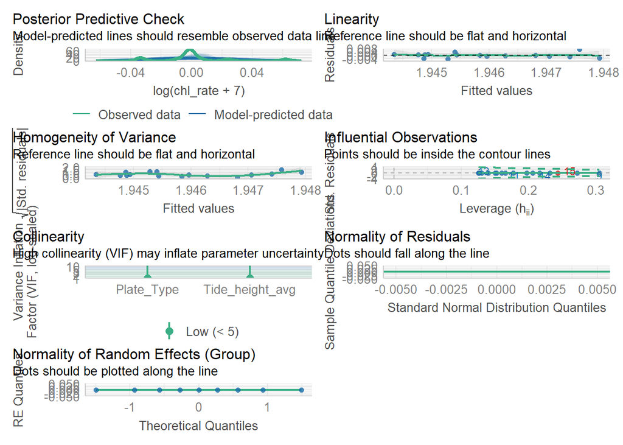

```r
check_model(chl_tide_lmer)
```

```r
ggsave(here("Output", "Chl_tide_Check_Model.png"))
```

#joined normalized chl and limpet weight boxplots

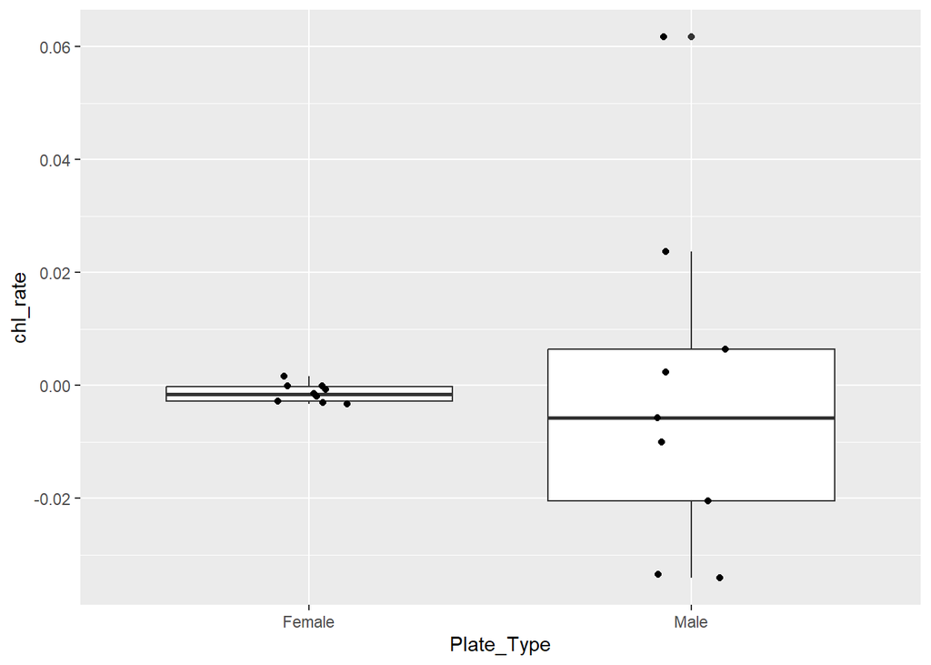

```r
norm_chl_weight_box <- norm_chl_weight %>%
  filter(Plate_Type != "Control") %>%
  ggplot(aes(x= Plate_Type,
             y=chl_rate))+
  geom_boxplot()+
  geom_jitter(width = 0.1)
norm_chl_weight_box
```

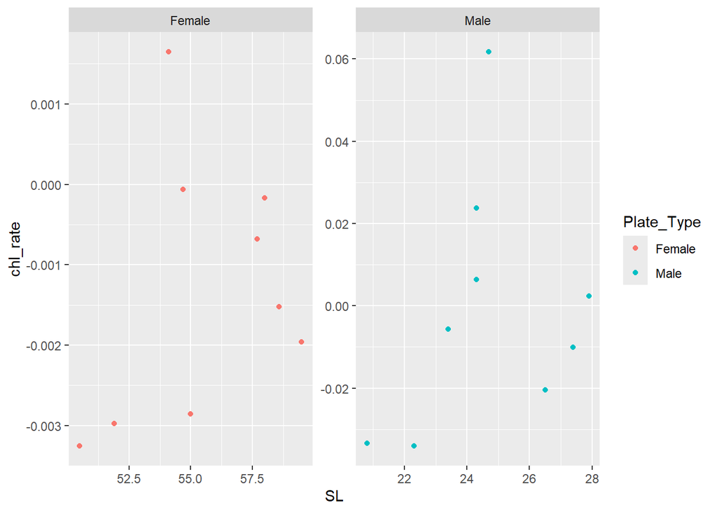

```r
chl_body_size_scatter <- norm_chl_weight %>%
  filter(Plate_Type != "Control") %>%
  ggplot(aes(x= SL,
             y = chl_rate))+
  geom_point(aes(color = Plate_Type))+
  facet_wrap(~Plate_Type, scales = "free")
chl_body_size_scatter
```

#Chl Concentration Boxplot

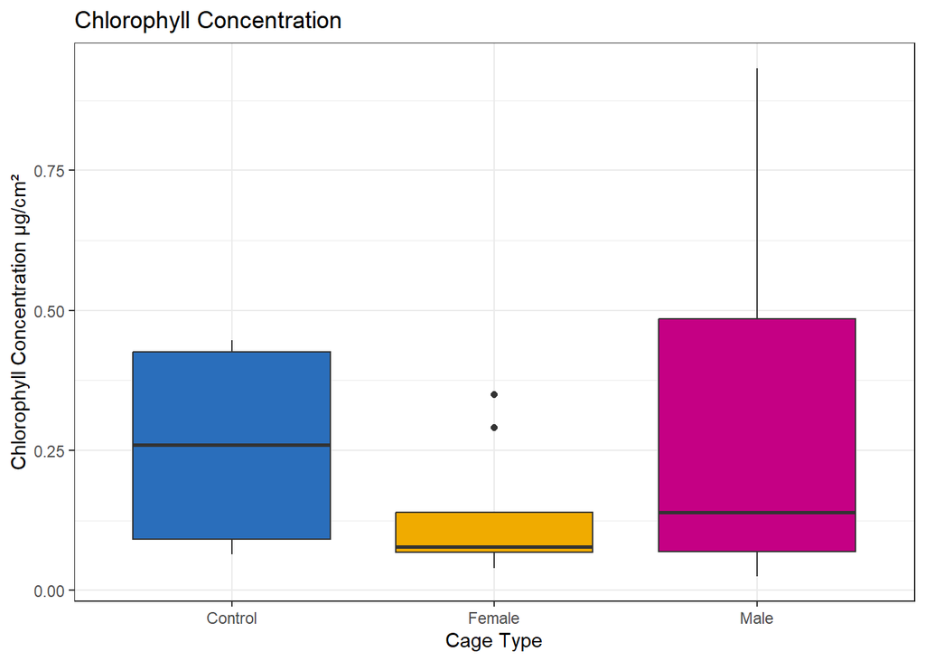

```r
chl_conc_boxplot <-chl_abun %>%
  filter(Plate_Type != "Unknown") %>%
  ggplot(aes(x=Plate_Type,
         y = mean_ug_cm2,
         fill = Plate_Type))+
  geom_boxplot(show.legend = FALSE)+
  labs(title = "Chlorophyll Concentration",
       fill = "Plate_Type",
       x = "Cage Type",
       y = "Chlorophyll Concentration μg/cm²")+
  scale_fill_bmj()+
  theme_bw()

chl_conc_boxplot
```

#Only Females and Males

```r
orig_only_fem_male <- orig_spec_chl_abun %>%
  separate(col = Plate_ID,
           into = c("Plate", "ID"),
           sep = "_") %>%
  mutate(Path_length_cm = Path_lenght_mm/10) %>%
  mutate(ug_ml = ((Abun_665-Abun_750)/Path_length_cm),
         ug = ug_ml *Metha_vol,
         ug_cm2 = ug/SA_cm_2) %>%
  group_by(Plate, Group) %>%
  summarise(mean_ug_cm2 = mean(ug_cm2 ),
            se_ug_cm2 = sd(ug_cm2)/sqrt(n())) %>%
  mutate(Group = as.factor(Group)) %>%
  mutate(Plate_Type = case_when(
    Plate %in% c("C1","C2","C3","C4") ~ "Control",
    Plate %in% c("F1","F2","F3","F4","F6","F7","F8","F10","F5") ~ "Female",
    Plate %in% c("M1","M2","M3","M4","M5","M6","M8","M9","M10") ~ "Male",
    Plate %in% ("UK") ~ "Unknown")) %>%
  filter(Plate_Type != "Control") %>%
  filter(Plate_Type != "Unknown") %>%
  mutate(Group = case_when(
    Plate %in% c("F1", "M1") ~ "1",
    Plate %in% c("F2", "M2") ~ "2",
    Plate %in% c("F3", "M3") ~ "3",
    Plate %in% c ("F4", "M4") ~ "4",
    Plate %in% c("F5", "M5") ~ "5",
    Plate %in% c("F6", "M6") ~ "6",
    Plate %in% c("F7") ~"7",
    Plate %in% c("F8", "M8") ~"8",
    Plate %in% c("M9") ~ "9",
    Plate %in% c("F10", "M10") ~"10"))
```

#Chlorophyl Paired Graph

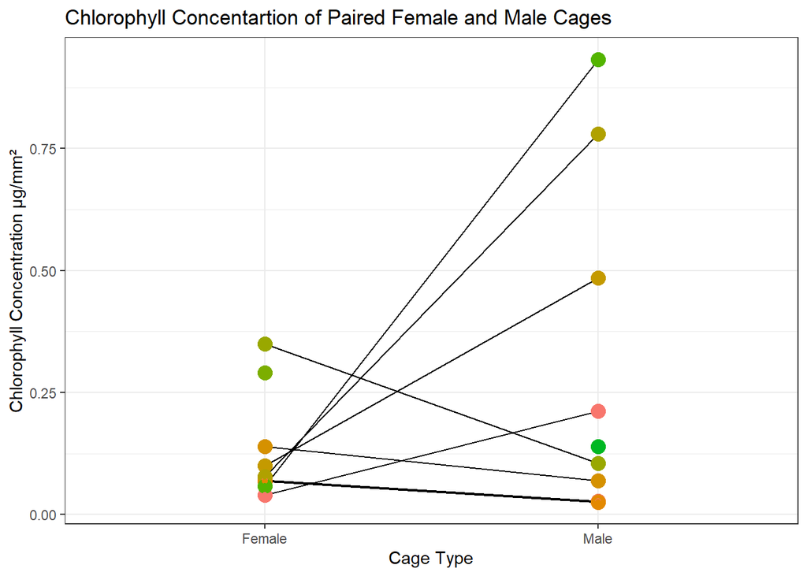

```r
orig_paired_graph <- orig_only_fem_male %>%
  ggplot(aes(x = Plate_Type,
             y = mean_ug_cm2)) +
  stat_summary(aes(group = Group),
               fun = mean,
               geom = "path",
               show.legend = FALSE) +
  stat_summary(aes(color = Plate),
               fun.data = mean_cl_boot,
               show.legend = FALSE) +
  stat_summary(aes(color = Group),
               fun = mean,
               geom = "point",
               size = 4,
               show.legend = FALSE) +
  geom_point(aes(color = Group),
             show.legend = FALSE)+
  labs(title = "Chlorophyll Concentartion of Paired Female and Male Cages",
       x = "Cage Type",
       y = "Chlorophyll Concentration μg/mm²")+
  theme_bw()

orig_paired_graph
```

#General Linear Models Error in initializePtr() : function ‘cholmod_factor_ldetA’ not provided by package ‘Matrix’

```r
#Mod_chl<-lmer(mean_ug_cm2~Plate_Type+(1|Group), data = orig_only_fem_male %>%
               #filter(Plate_Type %in% c("Male","Female")))
#anova(Mod_chl)
#summary(Mod_chl)

#post hoc test
#emmeans(Mod_chl, list(pairwise~Plate_Type), adjust = "tukey")
```

#PAM Data Manipulation For Plate Type per date

```r
PAM_average_Jun_Nine <- master_PAM %>%
  filter(Date != "2024_06_24") %>%
  group_by(Plate_ID, Group, Plate_Type) %>%
  mutate(sd_F0 = sd(F0),
         mean_F0 = mean(F0))

PAM_average_Jun_24<- master_PAM %>%
  filter(Date == "2024_06_24") %>%
  group_by(Plate_ID, Group, Plate_Type) %>%
  mutate(mean_F0 = mean(F0),
         sd_F0 = sd(F0))
```

#PAM Data Boxplots

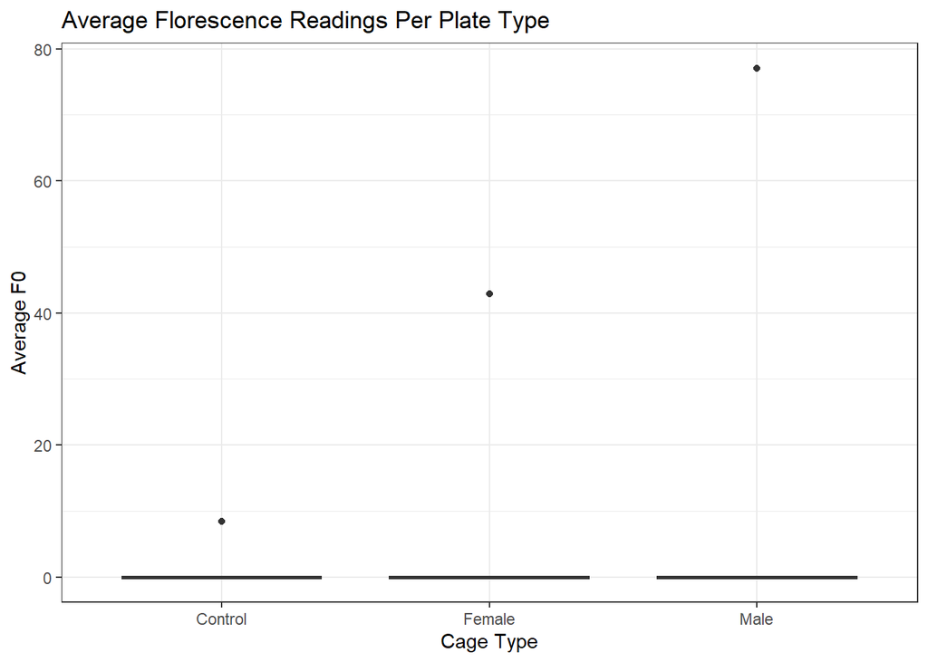

```r
June_Nine_PAM_boxplot <- ggplot(PAM_average_Jun_Nine,
                      aes(x=Plate_Type,
                          y=mean_F0,
                          fill=Plate_Type))+
  geom_boxplot(show.legend = FALSE)+
  labs(title = "Average Florescence Readings Per Plate Type",
       x = "Cage Type",
       y = "Average F0")+
  scale_fill_bmj()+
  theme_bw()
June_Nine_PAM_boxplot
```

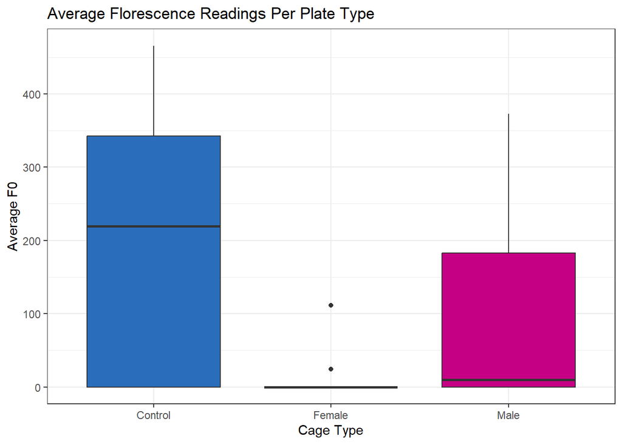

```r
June_24_PAM_boxplot<- ggplot(PAM_average_Jun_24,
                      aes(x=Plate_Type,
                          y=mean_F0,
                          fill=Plate_Type))+
  geom_boxplot(show.legend = FALSE)+
  labs(title = "Average Florescence Readings Per Plate Type",
       x = "Cage Type",
       y = "Average F0")+
  scale_fill_bmj()+
  theme_bw()
June_24_PAM_boxplot
```

#PAM Lineplot for Avegarges Per Cage

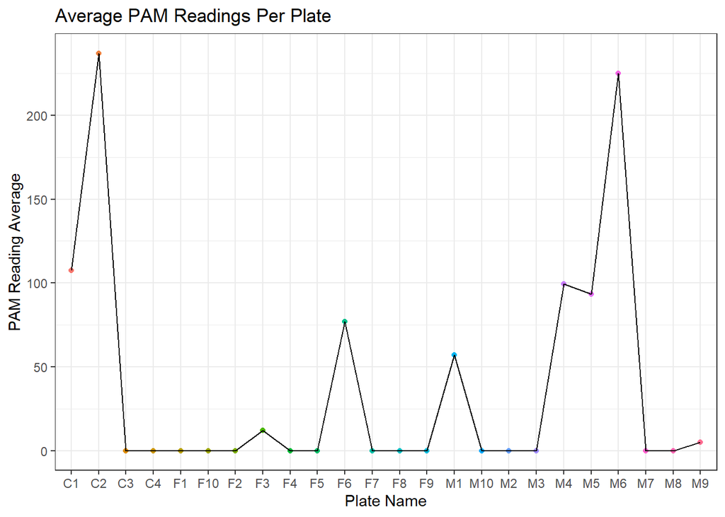

```r
PAM_ave_per_plate <- master_PAM %>%
  group_by(Plate_ID, Group) %>%
  summarise(PAM_average = mean(F0)) %>%
  mutate(log_F0 = log(PAM_average+1))

Plate_line_plot <- ggplot(PAM_ave_per_plate,
                      aes(x=Plate_ID,
                          y=PAM_average,
                          color = Plate_ID))+
  geom_point(show.legend = FALSE)+
  geom_line(color= "black",
            group=1,
            show.legend = FALSE)+
  labs(title = "Average PAM Readings Per Plate",
       x = "Plate Name",
       y = "PAM Reading Average")+
  scale_fill_bmj()+
  theme_bw()
Plate_line_plot
```

#Statistics for PAM Statistical question: Are the mean florescence different between male and female cages

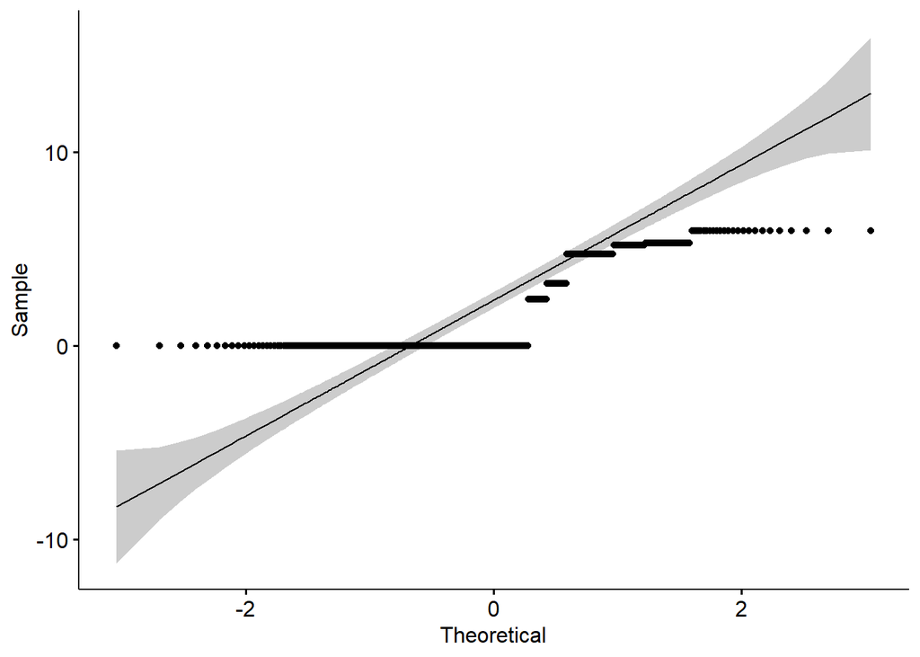

```r
#data manipulation for t test
mal_fem_fo <- PAM_average_Jun_24 %>%
  filter(Plate_Type!="Control") %>% #filtered out controls
  mutate(var_F0 = var(mean_F0),
         log_F0 = log(mean_F0+1)) #data was not normal, log transformed and added 1 since data had many 0's
ggqqplot(mal_fem_fo$log_F0) #check for normality
```

```r
F0_ttest <- t.test(log_F0~Plate_Type, var.equal=TRUE, data = mal_fem_fo)
F0_ttest
```

```
##
##  Two Sample t-test
##
## data:  log_F0 by Plate_Type
## t = -8.3732, df = 429, p-value = 8.028e-16
## alternative hypothesis: true difference in means between group Female and group Male is not equal to 0
## 95 percent confidence interval:
##  -2.139831 -1.326218
## sample estimates:
## mean in group Female   mean in group Male
##            0.8869624            2.6199871
```

```r
F0_average <- master_PAM %>%
  group_by(Plate_Type, Group) %>%
  summarise(mean_F0 = mean(F0)) %>%
  mutate(log_F0 = log(mean_F0+1))
F0_model <- lm(log_F0~Plate_Type, data = F0_average )
anova(F0_model)
```

```
## Analysis of Variance Table
##
## Response: log_F0
##            Df Sum Sq Mean Sq F value Pr(>F)
## Plate_Type  2 13.676  6.8380  1.4926 0.2477
## Residuals  21 96.206  4.5812
```

```r
summary(F0_model)
```

```
##
## Call:
## lm(formula = log_F0 ~ Plate_Type, data = F0_average)
##
## Residuals:
##     Min      1Q  Median      3Q     Max
## -2.5396 -2.0414 -0.6928  2.0525  3.6653
##
## Coefficients:
##                  Estimate Std. Error t value Pr(>|t|)
## (Intercept)        2.5396     1.0702   2.373   0.0273 *
## Plate_TypeFemale  -1.8468     1.2663  -1.458   0.1595
## Plate_TypeMale    -0.4982     1.2663  -0.393   0.6980
## ---
## Signif. codes:  0 '***' 0.001 '**' 0.01 '*' 0.05 '.' 0.1 ' ' 1
##
## Residual standard error: 2.14 on 21 degrees of freedom
## Multiple R-squared:  0.1245, Adjusted R-squared:  0.04108
## F-statistic: 1.493 on 2 and 21 DF,  p-value: 0.2477
```

#join PAM data and chlorophyll data This is a left join that was made before the addition of the June 9-10 data. Do I average out the F0 readings by date and then do the join?

```r
#full_data_PAM_CH <- PAM_average %>%
  #rename(Plate=Plate_ID) %>%
  #mutate(Group=factor(Group)) %>%
  #left_join(chl_abun)
```

#scatterplot of full data This was made with the joined data from above. Change as neccesary

```r
#scatter_full <- ggplot(full_data_PAM_CH,
                       #aes(x=mean_F0,
                           #y=mean_ug_cm2))+
  #geom_point()+
  #geom_smooth(method="lm") #regression line, add method = lm
#scatter_full
```

#PAM Average Grouped Data By Date

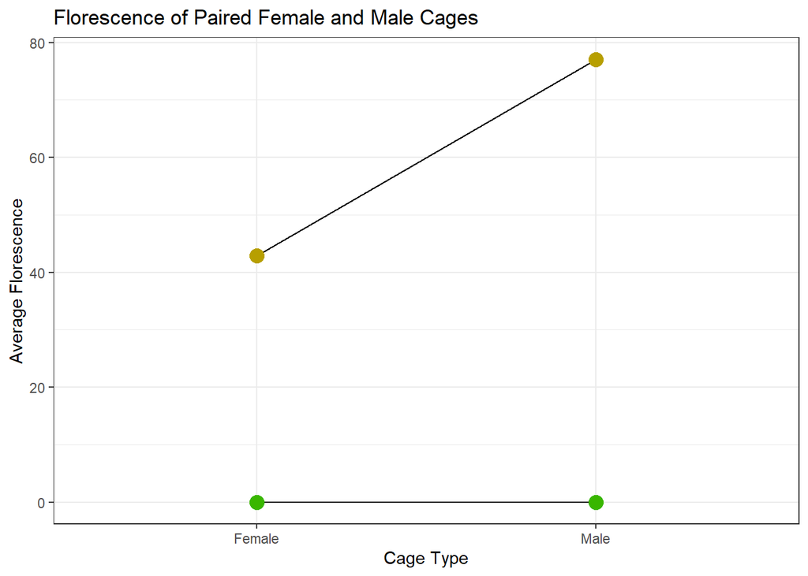

```r
PAM_average_Jun_9 <- master_PAM %>%
  filter(Date != "2024_06_24",
         Plate_Type != "Control") %>%
  group_by(Plate_Type, Group, Plate_ID) %>%
   mutate(Group = as.factor(Group)) %>%
  summarise(mean_F0 = mean(F0))

Jun_Nine_PAM_paired_graph <- PAM_average_Jun_9 %>%
  ggplot(aes(x = Plate_Type,
             y = mean_F0)) +
  stat_summary(aes(group = Group),
               fun = mean,
               geom = "path",
               show.legend = FALSE) +
  stat_summary(aes(color = Plate_ID),
               fun.data = mean_cl_boot,
               show.legend = FALSE) +
  stat_summary(aes(color = Group),
               fun = mean,
               geom = "point",
               size = 4,
               show.legend = FALSE) +
  geom_point(aes(color = Group),
             show.legend = FALSE)+
  labs(title = "Florescence of Paired Female and Male Cages",
       x = "Cage Type",
       y = "Average Florescence")+
  theme_bw()

Jun_Nine_PAM_paired_graph
```

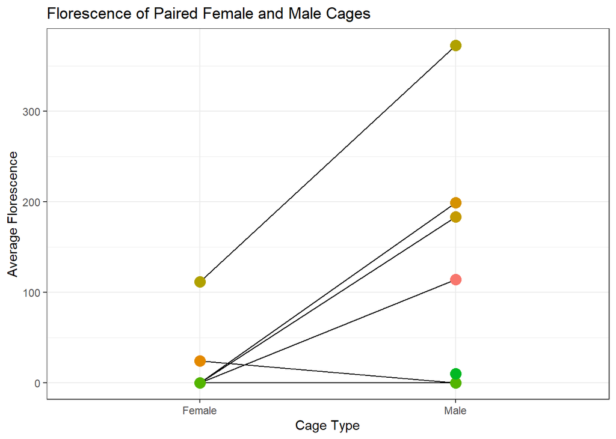

```r
PAM_average_6_24 <- master_PAM %>%
  filter(Date == "2024_06_24",
         Plate_Type != "Control") %>%
  group_by(Plate_Type, Group, Plate_ID) %>%
   mutate(Group = as.factor(Group)) %>%
  summarise(mean_F0 = mean(F0))

Jun_24_PAM_paired_graph <- PAM_average_6_24 %>%
  ggplot(aes(x = Plate_Type,
             y = mean_F0)) +
  stat_summary(aes(group = Group),
               fun = mean,
               geom = "path",
               show.legend = FALSE) +
  stat_summary(aes(color = Plate_ID),
               fun.data = mean_cl_boot,
               show.legend = FALSE) +
  stat_summary(aes(color = Group),
               fun = mean,
               geom = "point",
               size = 4,
               show.legend = FALSE) +
  geom_point(aes(color = Group),
             show.legend = FALSE)+
  labs(title = "Florescence of Paired Female and Male Cages",
       x = "Cage Type",
       y = "Average Florescence")+
  theme_bw()

Jun_24_PAM_paired_graph
```

#Chlorphyll raw data

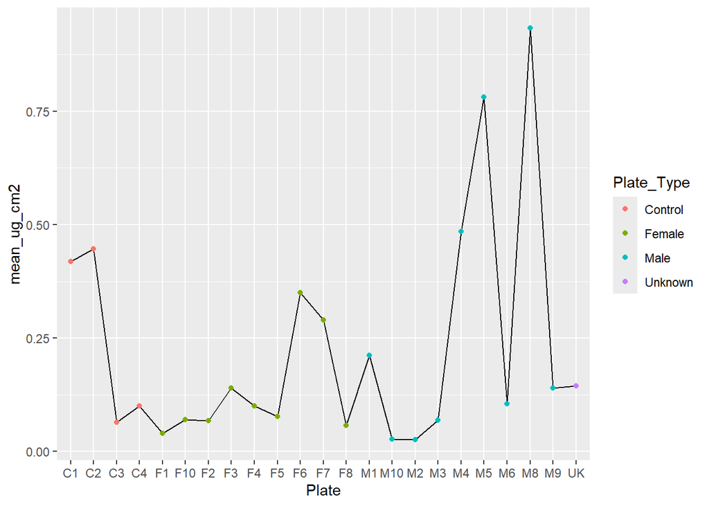

```r
chlorophyll_raw_ <- chl_abun %>%
  ggplot(aes(x = Plate,
             y = mean_ug_cm2))+
  geom_line(color= "black",
            group=1,
            show.legend = FALSE)+
  geom_point(aes(color = Plate_Type))

chlorophyll_raw_
```

#Raw data for PAM data per date

```r
PAM_sum_early_jun <- master_PAM %>%
  filter(Date != "2024_06_24") %>%
  group_by(Plate_ID, Group, Plate_Type) %>%
  mutate(F0_sum = sum(F0))

PAM_sum_late_jun <- master_PAM %>%
  filter(Date == "2024_06_24") %>%
  group_by(Plate_ID, Group, Plate_Type) %>%
  mutate(F0_sum = sum(F0))
```

#Line plot of summed F0 per data

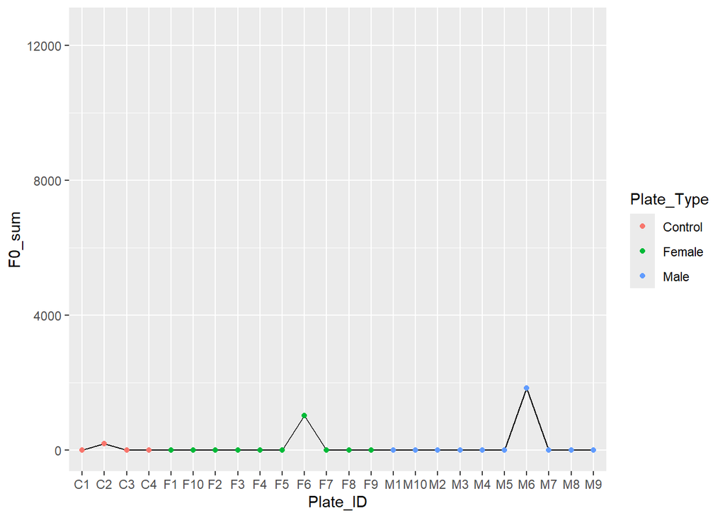

```r
early_jun_raw <- PAM_sum_early_jun %>%
  ggplot(aes(x = Plate_ID,
             y = F0_sum))+
  geom_line(color= "black",
            group=1,
            show.legend = FALSE)+
  geom_point(aes(color = Plate_Type))+
  scale_y_continuous(limits = c(0,12500))

early_jun_raw
```

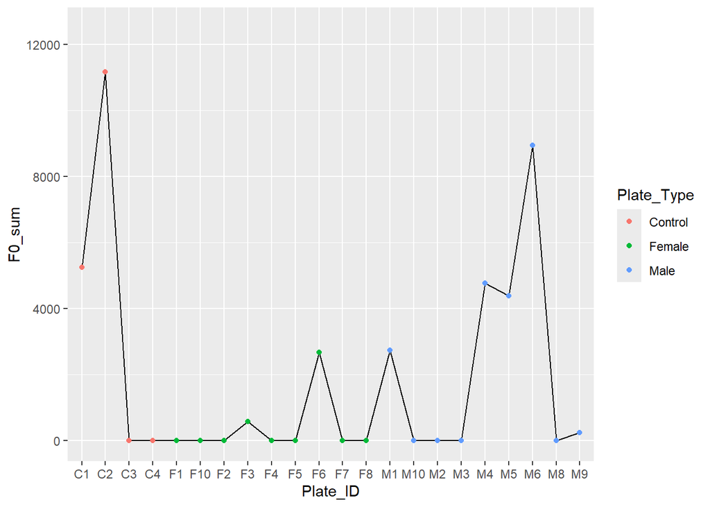

```r
late_jun_raw<- PAM_sum_late_jun %>%
  ggplot(aes(x = Plate_ID,
             y = F0_sum))+
  geom_line(color= "black",
            group=1,
            show.legend = FALSE)+
  geom_point(aes(color = Plate_Type))+
  scale_y_continuous(limits = c(0,12500))

late_jun_raw
```

#Kurtosis For the chlorophyll data, do I look at the kurtosis of the raw absorbency at 665nm and 750nm or do I do the kurtosis for the mean chlorophyll concentration? Below I did it for th mean chlorophyll concentration. The same goes for the PAM data. Do I separate it by date? Do I look at the raw F0? The mean, the sum? Below I looked at the raw FO per date

```r
chl_kurtosis <- kurtosis(chl_abun$mean_ug_cm2)
chl_kurtosis #kurtosis is >3, not normal
```

```
## [1] 4.896605
```

```r
chl_skewness <- skewness(chl_abun$mean_ug_cm2)
chl_skewness #skewness is 1.65, not normal
```

```
## [1] 1.648246
```

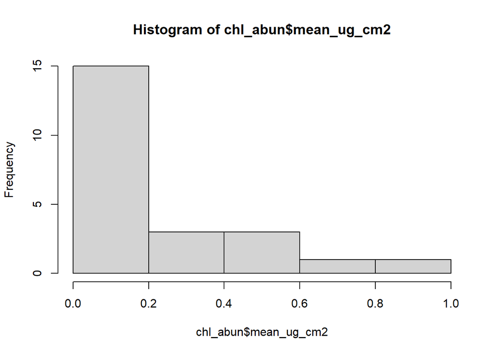

```r
chl_hist <- hist(chl_abun$mean_ug_cm2)
```

```r
early_june <- master_PAM %>%
  filter(Date!="2024_06_24")
early_jun_PAM_kurtosis <- kurtosis(early_june$F0)
early_jun_PAM_kurtosis #kurtosis is 55.48, wild
```

```
## [1] 55.47831
```

```r
late_jun <- master_PAM %>%
  filter(Date=="2024_06_24")
late_jun_kurtosis <- kurtosis(late_jun$F0)
late_jun_kurtosis #kurtosis is 8.34, not normal
```

```
## [1] 8.34338
```

#Coefficient of Variant Below I did the CV for Chlorophyll abundance average and Florescence average

```r
cv_chl_conc <- chl_abun %>%
  mutate(CV= (sd_ug_cm2/mean_ug_cm2)*100) #this gives me CV per plate, is that what I want?

cv_early_jun_Pam <- PAM_average_Jun_Nine %>%
  mutate(CV = (sd_F0/mean_F0)*100)

cv_late_jun_PAM <- PAM_average_Jun_24 %>%
  mutate(CV = (sd_F0/mean_F0)*100)
```